# cw7

Dawid Dąbkowski

25.04.2017

```r
library(PBImisc)
library(lattice)
library(lme4)
library(ggplot2)
```

Wczytamy dane dotyczące demencji.

```r
dane <- dementia
head(dane)
```

```
##   demscore  age    sex         study
## 1       53  <60   Male Poland Gdansk
## 2       36  <60   Male Poland Gdansk
## 3       74 >=60 Female Poland Gdansk
## 4       39 >=60   Male Poland Gdansk
## 5       63  <60 Female Poland Gdansk
## 6       55 >=60   Male Poland Gdansk
```

```r
summary(dane)
```

```
##     demscore       age          sex                    study
##  Min.   :  0.0   <60 :488   Female:498   Albania          :100
##  1st Qu.: 38.0   >=60:512   Male  :502   Estonia          :100
##  Median : 50.0                           Poland Gdansk    :100
##  Mean   : 50.5                           Poland Steszew   :100
##  3rd Qu.: 63.0                           Poland Swiebodzin:100
##  Max.   :100.0                           Poland Tarnobrzeg:100
##                                          (Other)          :400
```

```r
#levels(dane$study)
```

## Wstępna analiza

Sprawdźmy najpierw model liniowy zależności demscore od wieku i płci.

```r
model1 <- lm(demscore ~ age * sex, data=dane)
summary(model1)
```

```
##
## Call:
## lm(formula = demscore ~ age * sex, data = dane)
##
## Residuals:
##     Min      1Q  Median      3Q     Max
## -45.579 -10.918   0.082  10.839  48.421
##
## Coefficients:
##                 Estimate Std. Error t value Pr(>|t|)
## (Intercept)      50.9183     0.9906  51.400  < 2e-16 ***
## age>=60           9.8410     1.4240   6.911 8.59e-12 ***
## sexMale         -11.6759     1.4398  -8.109 1.49e-15 ***
## age>=60:sexMale   1.4959     2.0125   0.743    0.457
## ---
## Signif. codes:  0 '***' 0.001 '**' 0.01 '*' 0.05 '.' 0.1 ' ' 1
##
## Residual standard error: 15.88 on 996 degrees of freedom
## Multiple R-squared:  0.1788, Adjusted R-squared:  0.1763
## F-statistic: 72.28 on 3 and 996 DF,  p-value: < 2.2e-16
```

```r
anova(model1)
```

```
## Analysis of Variance Table
##
## Response: demscore
##            Df Sum Sq Mean Sq  F value Pr(>F)
## age         1  24884 24884.3  98.6685 <2e-16 ***
## sex         1  29665 29664.6 117.6231 <2e-16 ***
## age:sex     1    139   139.3   0.5525 0.4575
## Residuals 996 251192   252.2
## ---
## Signif. codes:  0 '***' 0.001 '**' 0.01 '*' 0.05 '.' 0.1 ' ' 1
```

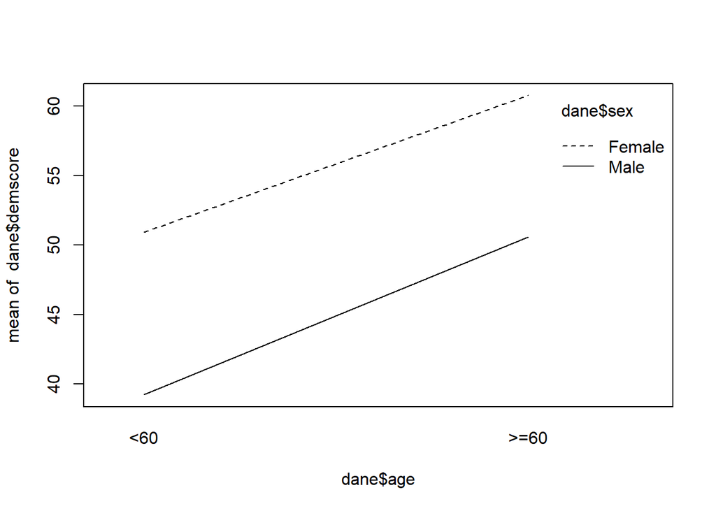

```r
interaction.plot(dane$age, dane$sex, dane$demscore)
```

Widzimy, że zarówno płeć jak i wiek są istotne. Nie widzimy natomiast istotnych interakcji wiek:płeć. Dalej nie będziemy więc uwzględniać interakcji między tymi efektami.

Zobaczmy jak wygląda model liniowy zależności demscore od placówki.

```r
model2 <- lm(demscore ~ study, data=dane)
anova(model2)
```

```
## Analysis of Variance Table
##
## Response: demscore
##            Df Sum Sq Mean Sq F value    Pr(>F)
## study       9  17660 1962.20  6.7399 2.015e-09 ***
## Residuals 990 288220  291.13
## ---
## Signif. codes:  0 '***' 0.001 '**' 0.01 '*' 0.05 '.' 0.1 ' ' 1
```

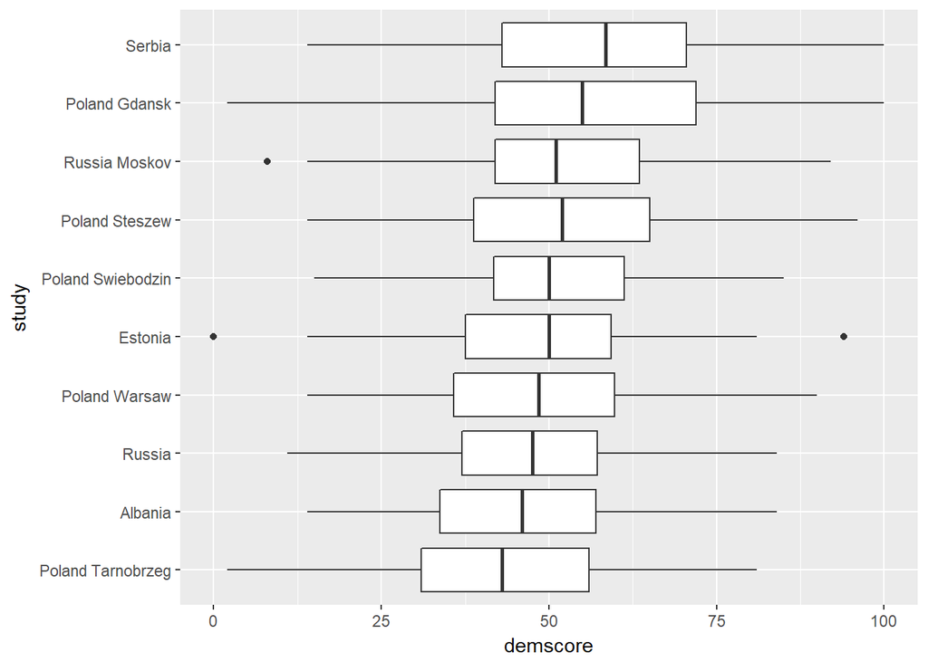

```r
ggplot(dane, aes(x = reorder(study, demscore, FUN = mean), y=demscore)) + geom_boxplot() + coord_flip() + xlab("study")
```

Widać tu istotne różnice w średniej ze względu na placówkę.

Placówkę możemy potraktować jako efekt mieszany. Stwórzmy odpowiedni model i zróbmy na nim testy ilorazu wiarogodności i test permutacyjny na istotność efektów (dla efektów stałych dodatkowo test Walda).

## Istotność losowego efektu ‘study’

```r
modelNoStudy <- lm(demscore ~ age + sex, data=dane)
modelFull <- lmer(demscore ~ age + sex + (1|study), data=dane)

anova(modelFull, modelNoStudy)
```

```
## refitting model(s) with ML (instead of REML)
```

```
## Data: dane
## Models:
## modelNoStudy: demscore ~ age + sex
## modelFull: demscore ~ age + sex + (1 | study)
##              Df    AIC    BIC  logLik deviance Chisq Chi Df Pr(>Chisq)
## modelNoStudy  4 8372.6 8392.3 -4182.3   8364.6
## modelFull     5 8345.8 8370.3 -4167.9   8335.8 28.87      1  7.739e-08 ***
## ---
## Signif. codes:  0 '***' 0.001 '**' 0.01 '*' 0.05 '.' 0.1 ' ' 1
```

```r
#LogLik(modelFull), LogLik(modelNoStudy)
```

Z testu ilorazu wiarogodności widzimy, że efekt losowy study jest istotny.

```r
(sigma_m <- modelFull@theta)
```

```
## [1] 0.2321686
```

```r
m <- 1000
sigma_r <- c()

for (i in 1:(m-1)){
  dane$study2 <- sample(dane$study)
  model_r <- lmer(demscore ~ age + sex + (1|study2), data=dane)
  sigma_r[i] <- model_r@theta
}
```

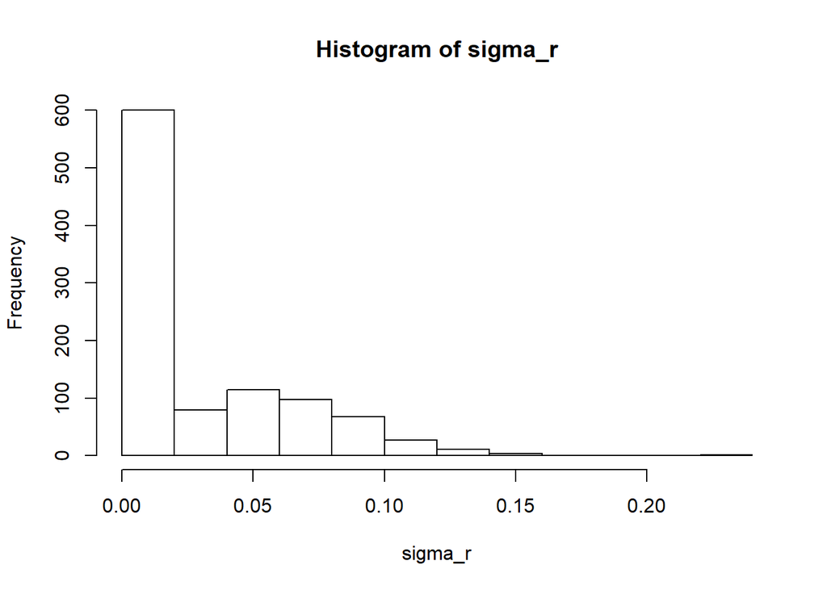

```r
sigma_r[m] <- sigma_m

hist(sigma_r)
```

```r
mean(sigma_r >= sigma_m)
```

```
## [1] 0.001
```

Potwierdza to również test permutacyjny. Otrzymaliśmy najmniejszą możliwą p-wartość (jedyna sigma z próbki, która nie jest mniejsza od prawdziwej sigmy to ona sama).

```r
summary(modelFull)
```

```
## Linear mixed model fit by REML ['lmerMod']
## Formula: demscore ~ age + sex + (1 | study)
##    Data: dane
##
## REML criterion at convergence: 8329.9
##
## Scaled residuals:
##      Min       1Q   Median       3Q      Max
## -2.81685 -0.68426  0.00587  0.67016  2.97104
##
## Random effects:
##  Groups   Name        Variance Std.Dev.
##  study    (Intercept)  12.96    3.60
##  Residual             240.43   15.51
## Number of obs: 1000, groups:  study, 10
##
## Fixed effects:
##             Estimate Std. Error t value
## (Intercept)  50.5868     1.4171   35.70
## age>=60      10.3060     0.9854   10.46
## sexMale     -10.6822     0.9898  -10.79
##
## Correlation of Fixed Effects:
##         (Intr) ag>=60
## age>=60 -0.335
## sexMale -0.330 -0.059
```

```r
t.values <- summary(modelFull)$coefficients[,3]
2*pnorm(abs(t.values[1]), lower.tail=F)
```

```
##   (Intercept)
## 4.389382e-279
```

```r
2*pnorm(abs(t.values[2]), lower.tail=F)
```

```
##     age>=60
## 1.33419e-25
```

```r
2*pnorm(abs(t.values[3]), lower.tail=F)
```

```
##      sexMale
## 3.737566e-27
```

Test Walda wskazuje na istotność efektów age oraz sex.

## Istotność stałego efektu ‘age’

```r
modelNoAge <- lmer(demscore ~ sex + (1|study), data=dane)
anova(modelFull, modelNoAge)
```

```
## refitting model(s) with ML (instead of REML)
```

```
## Data: dane
## Models:
## modelNoAge: demscore ~ sex + (1 | study)
## modelFull: demscore ~ age + sex + (1 | study)
##            Df    AIC    BIC  logLik deviance  Chisq Chi Df Pr(>Chisq)
## modelNoAge  4 8447.9 8467.5 -4220.0   8439.9
## modelFull   5 8345.8 8370.3 -4167.9   8335.8 104.13      1  < 2.2e-16 ***
## ---
## Signif. codes:  0 '***' 0.001 '**' 0.01 '*' 0.05 '.' 0.1 ' ' 1
```

```r
#LogLik(model3a), LogLik(model3b)
```

Test ilorazu wiarogodności wskazuje na istotność efektu age.

```r
(sigma_m <- modelFull@theta)
```

```
## [1] 0.2321686
```

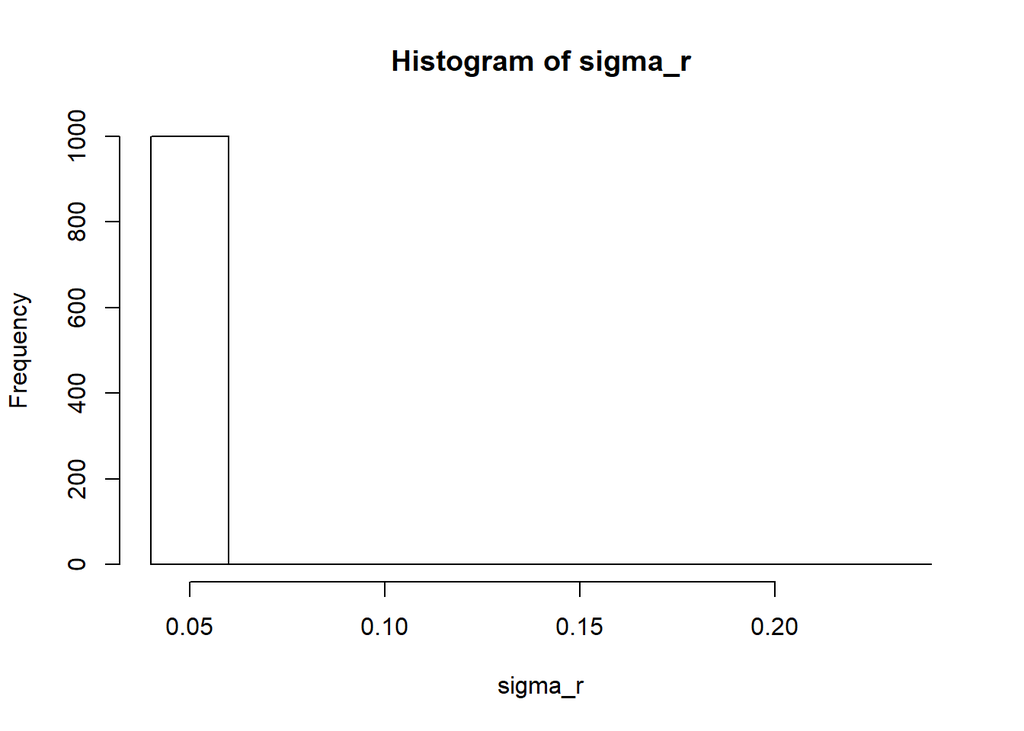

```r
m <- 1000
sigma_r <- c()

for (i in 1:(m-1)){
  dane$age2 <- sample(dane$age)
  model_r <- lmer(demscore ~ age + sex + (1|study2), data=dane)
  sigma_r[i] <- model_r@theta
}
sigma_r[m] <- sigma_m

hist(sigma_r)
```

```r
mean(sigma_r >= sigma_m)
```

```
## [1] 0.001
```

```r
modelNoSex <- lmer(demscore ~ age + (1|study), data=dane)
anova(modelFull, modelNoAge)
```

```
## refitting model(s) with ML (instead of REML)
```

```
## Data: dane
## Models:
## modelNoAge: demscore ~ sex + (1 | study)
## modelFull: demscore ~ age + sex + (1 | study)
##            Df    AIC    BIC  logLik deviance  Chisq Chi Df Pr(>Chisq)
## modelNoAge  4 8447.9 8467.5 -4220.0   8439.9
## modelFull   5 8345.8 8370.3 -4167.9   8335.8 104.13      1  < 2.2e-16 ***
## ---
## Signif. codes:  0 '***' 0.001 '**' 0.01 '*' 0.05 '.' 0.1 ' ' 1
```

```r
#LogLik(model3a), LogLik(model3b)
```

```r
(sigma_m <- modelFull@theta)
```

```
## [1] 0.2321686
```

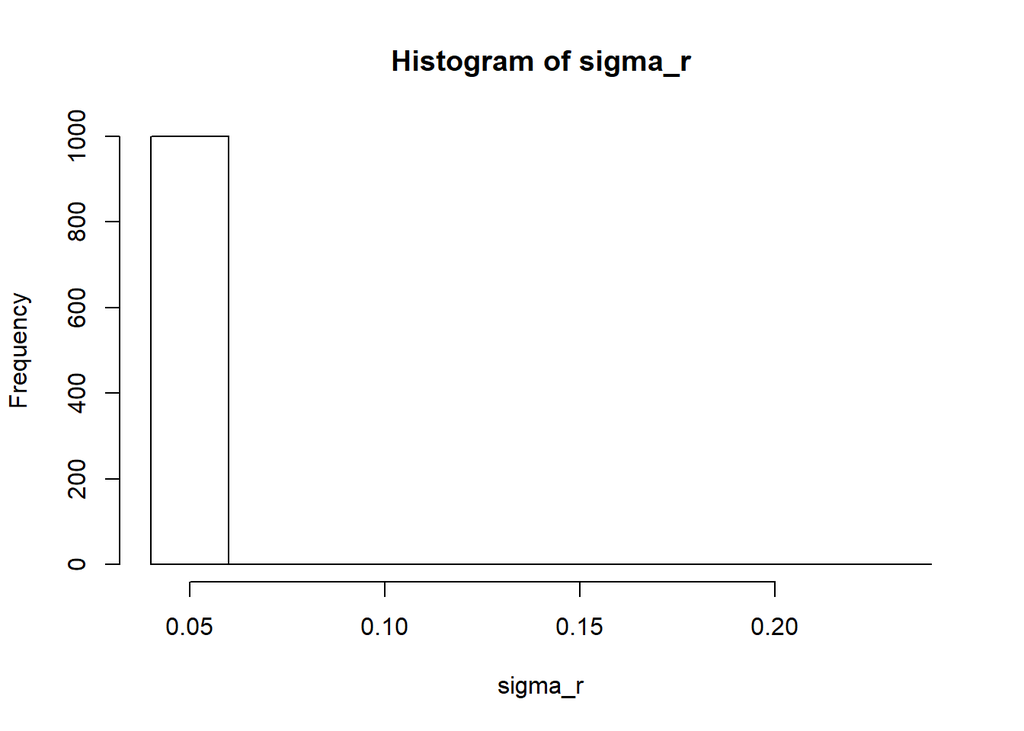

```r
m <- 1000
sigma_r <- c()

for (i in 1:(m-1)){
  dane$sex2 <- sample(dane$sex)
  model_r <- lmer(demscore ~ age + sex + (1|study2), data=dane)
  sigma_r[i] <- model_r@theta
}
sigma_r[m] <- sigma_m

hist(sigma_r)
```

```r
mean(sigma_r >= sigma_m)
```

```
## [1] 0.001
```